# Panel semana x cuadrante — SAIDI/SAIFI: infraestructura, NDVI y cuadrantes reales

## Composición real de usuarios por estrato y tipo (reemplaza el estrato municipal predominante)

La entrega final del compañero de tesis trae la composición **real, por cuadrante**, de usuarios por estrato socioeconómico (`ESTRATO_1` a `ESTRATO_6`) y por tipo de uso (`INDUSTRIAL`, `COMERCIAL`, `OFICIAL`, `PROVISIONAL`, `ALUMBRADO_PUBLICO`). Esto **reemplaza y mejora sustancialmente** al `estrato_predominante_municipal` usado hasta ahora (documento de estratificación municipal): antes solo se sabía el estrato predominante del **municipio**; ahora se sabe la composición exacta de usuarios **dentro del propio cuadrante**.

**El documento de estratificación municipal no se elimina** — queda como fuente secundaria/de respaldo y para contexto departamental (útil, por ejemplo, en los mapas de la Parte 5), pero las variables de modelación pasan a construirse desde estas columnas reales.

```r
cols_estrato <- c("ESTRATO_1", "ESTRATO_2", "ESTRATO_3", "ESTRATO_4", "ESTRATO_5", "ESTRATO_6",
                  "INDUSTRIAL", "COMERCIAL", "OFICIAL", "PROVISIONAL", "ALUMBRADO_PUBLICO")

faltantes_estrato <- setdiff(cols_estrato, names(data_final))
if (length(faltantes_estrato) > 0) {
  stop("Faltan columnas de composición de estrato: ", paste(faltantes_estrato, collapse = ", "))
}

# Verificación: la suma de todas las categorías debe coincidir con
# cantidad_usuarios_cuadrante (según lo indicado por el compañero de tesis)
verificacion_suma_estrato <- data_final %>%
  mutate(
    suma_categorias = rowSums(across(all_of(cols_estrato)), na.rm = TRUE),
    diff_suma = abs(suma_categorias - cantidad_usuarios_cuadrante)
  ) %>%
  summarise(
    max_diff  = max(diff_suma, na.rm = TRUE),
    media_diff = mean(diff_suma, na.rm = TRUE),
    pct_filas_ok = round(100 * mean(diff_suma < 1e-6), 1)
  )

kable(verificacion_suma_estrato, digits = 4,
      caption = "Verificacion: suma de ESTRATO_1..6 + tipos de uso vs. cantidad_usuarios_cuadrante") %>%
  kable_styling(bootstrap_options = c("striped"), full_width = FALSE)
```

Verificacion: suma de ESTRATO_1..6 + tipos de uso vs. cantidad_usuarios_cuadrante

| max_diff | media_diff | pct_filas_ok |
| --- | --- | --- |
| 1 | 9e-04 | 99.9 |

```r
if (verificacion_suma_estrato$max_diff > 1) {
  cat("\nADVERTENCIA: la suma de categorias no coincide exactamente con cantidad_usuarios_cuadrante en algunas filas. Revisar con el compañero de tesis si hay una categoria adicional no incluida (p. ej. usuarios sin categoria asignada).\n")
} else {
  cat("\nVerificacion correcta: la composicion por estrato y tipo reconstruye el total de usuarios del cuadrante.\n")
}
```

```
##
## Verificacion correcta: la composicion por estrato y tipo reconstruye el total de usuarios del cuadrante.
```

```r
# Proporciones (0-1) de cada categoria sobre el total de usuarios del
# cuadrante — más útiles para el modelo que los conteos absolutos,
# porque no están dominadas por el tamaño del cuadrante.
data_final <- data_final %>%
  mutate(
    prop_estrato_1 = if_else(cantidad_usuarios_cuadrante > 0, ESTRATO_1 / cantidad_usuarios_cuadrante, 0),
    prop_estrato_2 = if_else(cantidad_usuarios_cuadrante > 0, ESTRATO_2 / cantidad_usuarios_cuadrante, 0),
    prop_estrato_3 = if_else(cantidad_usuarios_cuadrante > 0, ESTRATO_3 / cantidad_usuarios_cuadrante, 0),
    prop_estrato_4 = if_else(cantidad_usuarios_cuadrante > 0, ESTRATO_4 / cantidad_usuarios_cuadrante, 0),
    prop_estrato_5 = if_else(cantidad_usuarios_cuadrante > 0, ESTRATO_5 / cantidad_usuarios_cuadrante, 0),
    prop_estrato_6 = if_else(cantidad_usuarios_cuadrante > 0, ESTRATO_6 / cantidad_usuarios_cuadrante, 0),
    prop_industrial   = if_else(cantidad_usuarios_cuadrante > 0, INDUSTRIAL / cantidad_usuarios_cuadrante, 0),
    prop_comercial    = if_else(cantidad_usuarios_cuadrante > 0, COMERCIAL / cantidad_usuarios_cuadrante, 0),
    prop_oficial      = if_else(cantidad_usuarios_cuadrante > 0, OFICIAL / cantidad_usuarios_cuadrante, 0),
    prop_provisional  = if_else(cantidad_usuarios_cuadrante > 0, PROVISIONAL / cantidad_usuarios_cuadrante, 0),
    prop_alumbrado    = if_else(cantidad_usuarios_cuadrante > 0, ALUMBRADO_PUBLICO / cantidad_usuarios_cuadrante, 0),

    # Estrato modal REAL (el de mayor conteo dentro del propio
    # cuadrante) — reemplaza al estrato predominante municipal como
    # variable categórica resumen, ahora con precisión de cuadrante
    estrato_modal_real = cols_estrato[1:6][max.col(across(all_of(cols_estrato[1:6])), ties.method = "first")],
    estrato_modal_real = as.integer(gsub("ESTRATO_", "", estrato_modal_real)),

    # Indicador de zona no residencial (industrial/comercial/oficial
    # predominante sobre lo residencial)
    prop_no_residencial = prop_industrial + prop_comercial + prop_oficial
  )

cat("Distribucion de estrato_modal_real (a nivel de cuadrante, no municipal):\n")
```

```
## Distribucion de estrato_modal_real (a nivel de cuadrante, no municipal):
```

```r
print(table(data_final %>% distinct(id_cuadrante, estrato_modal_real) %>% pull(estrato_modal_real)))
```

```
##
##   1   2
## 147 206
```

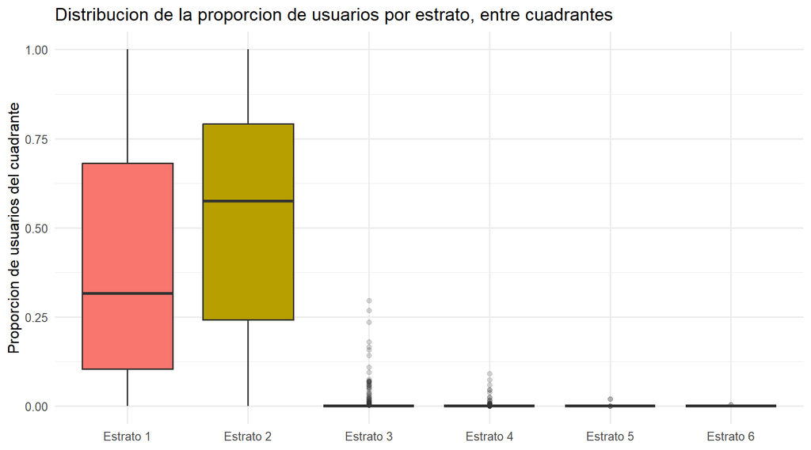

```r
data_final %>%
  distinct(id_cuadrante, .keep_all = TRUE) %>%
  select(id_cuadrante, starts_with("prop_estrato")) %>%
  pivot_longer(-id_cuadrante, names_to = "estrato", values_to = "proporcion") %>%
  mutate(estrato = gsub("prop_estrato_", "Estrato ", estrato)) %>%
  ggplot(aes(x = estrato, y = proporcion, fill = estrato)) +
  geom_boxplot(outlier.alpha = 0.2) +
  labs(
    title = "Distribucion de la proporcion de usuarios por estrato, entre cuadrantes",
    x = NULL, y = "Proporcion de usuarios del cuadrante"
  ) +
  theme_minimal(base_size = 12) +
  theme(legend.position = "none")
```

## Activos: edad y mantenimiento (variable pendiente, ahora resuelta)

Se incorporan `FECHA_ACTIVO_MAS_VIEJO`, `FECHA_ACTIVO_MAS_NUEVO` y `PROM_CANT_MODIFICACIONES` — las variables de mantenimiento/condición de la red que se habían identificado como el hueco más importante frente a los objetivos de la tesis (infraestructura hasta ahora medía solo *cantidad y composición*, nunca *condición* o *antigüedad*).

```r
cols_activos <- c("FECHA_ACTIVO_MAS_VIEJO", "FECHA_ACTIVO_MAS_NUEVO", "PROM_CANT_MODIFICACIONES")
faltantes_activos <- setdiff(cols_activos, names(data_final))
if (length(faltantes_activos) > 0) {
  stop("Faltan columnas de activos: ", paste(faltantes_activos, collapse = ", "))
}

cat("Resumen de fechas de activos:\n")
```

```
## Resumen de fechas de activos:
```

```r
print(summary(data_final %>% distinct(id_cuadrante, .keep_all = TRUE) %>%
                select(FECHA_ACTIVO_MAS_VIEJO, FECHA_ACTIVO_MAS_NUEVO, PROM_CANT_MODIFICACIONES)))
```

```
##  FECHA_ACTIVO_MAS_VIEJO FECHA_ACTIVO_MAS_NUEVO PROM_CANT_MODIFICACIONES
##  Min.   :2025-02-26     Min.   :2025-03-11     Min.   :1.000
##  1st Qu.:2026-06-02     1st Qu.:2026-06-03     1st Qu.:1.067
##  Median :2026-06-02     Median :2026-06-03     Median :1.125
##  Mean   :2026-03-16     Mean   :2026-06-26     Mean   :1.189
##  3rd Qu.:2026-06-02     3rd Qu.:2026-07-27     3rd Qu.:1.240
##  Max.   :2026-08-03     Max.   :2026-09-01     Max.   :3.000
##  NA's   :1              NA's   :1              NA's   :1
```

```r
# ------------------------------------------------------------------
# Edad de activos: se calcula relativa a CADA semana del panel (no a
# hoy), para que la variable varíe correctamente en el tiempo — un
# activo instalado en 2020 tiene distinta "edad" en enero 2024 que en
# diciembre 2025. FECHA_ACTIVO_MAS_VIEJO/MAS_NUEVO se asumen fijas
# por cuadrante (el activo más viejo/nuevo EN OPERACION en el momento
# del corte de datos de la entrega) — si en el futuro se actualizan
# por semana, este calculo seguira funcionando igual.
# ------------------------------------------------------------------
data_final <- data_final %>%
  mutate(
    edad_activo_mas_viejo_dias = as.numeric(semana - FECHA_ACTIVO_MAS_VIEJO),
    edad_activo_mas_nuevo_dias = as.numeric(semana - FECHA_ACTIVO_MAS_NUEVO),
    edad_activo_mas_viejo_anios = edad_activo_mas_viejo_dias / 365.25,
    edad_activo_mas_nuevo_anios = edad_activo_mas_nuevo_dias / 365.25,
    rango_edad_activos_anios = edad_activo_mas_viejo_anios - edad_activo_mas_nuevo_anios
  )

cat(sprintf(
  "Edad activo mas viejo (anios) — media: %.1f | mediana: %.1f | max: %.1f\n",
  mean(data_final$edad_activo_mas_viejo_anios, na.rm = TRUE),
  median(data_final$edad_activo_mas_viejo_anios, na.rm = TRUE),
  max(data_final$edad_activo_mas_viejo_anios, na.rm = TRUE)
))
```

```
## Edad activo mas viejo (anios) — media: -1.2 | mediana: -1.2 | max: 0.8
```

```r
cat(sprintf(
  "Rango de edad entre activos del cuadrante (anios) — media: %.1f | mediana: %.1f\n",
  mean(data_final$rango_edad_activos_anios, na.rm = TRUE),
  median(data_final$rango_edad_activos_anios, na.rm = TRUE)
))
```

```
## Rango de edad entre activos del cuadrante (anios) — media: 0.3 | mediana: 0.1
```

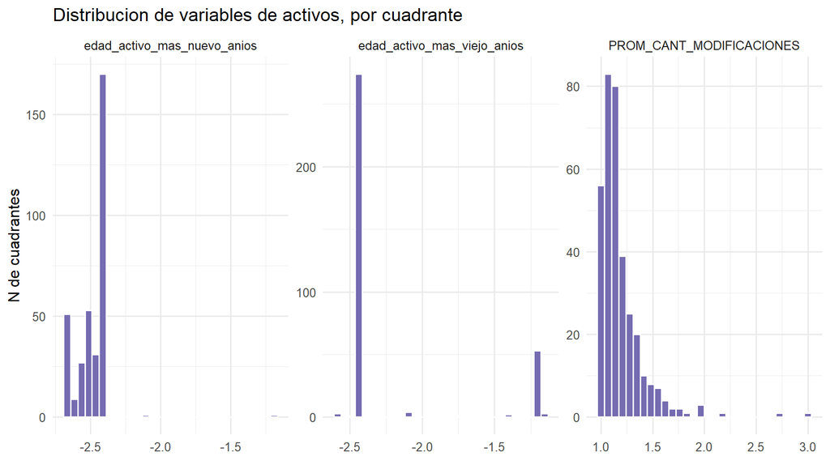

```r
data_final %>%
  distinct(id_cuadrante, .keep_all = TRUE) %>%
  select(edad_activo_mas_viejo_anios, edad_activo_mas_nuevo_anios, PROM_CANT_MODIFICACIONES) %>%
  pivot_longer(everything(), names_to = "variable", values_to = "valor") %>%
  ggplot(aes(x = valor)) +
  geom_histogram(bins = 30, fill = "#756bb1", color = "white") +
  facet_wrap(~variable, scales = "free") +
  labs(title = "Distribucion de variables de activos, por cuadrante", x = NULL, y = "N de cuadrantes") +
  theme_minimal(base_size = 12)
```

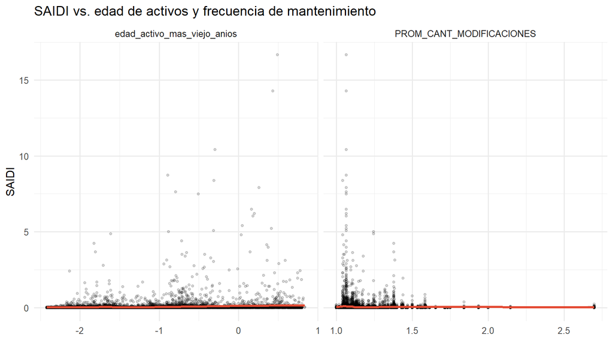

```r
data_final %>%
  filter(hubo_falla == 1) %>%
  select(SAIDI, edad_activo_mas_viejo_anios, PROM_CANT_MODIFICACIONES) %>%
  pivot_longer(-SAIDI, names_to = "variable", values_to = "valor") %>%
  ggplot(aes(x = valor, y = SAIDI)) +
  geom_point(alpha = 0.15, size = 1) +
  geom_smooth(method = "loess", color = "#e34a33", se = TRUE) +
  facet_wrap(~variable, scales = "free_x") +
  labs(title = "SAIDI vs. edad de activos y frecuencia de mantenimiento", x = NULL, y = "SAIDI") +
  theme_minimal(base_size = 12)
```

**Interpretación esperada:** `edad_activo_mas_viejo_anios` alta puede asociarse con mayor SAIDI (activos más antiguos, más propensos a fallar). `PROM_CANT_MODIFICACIONES` es ambiguo a priori: puede reflejar **mantenimiento preventivo activo** (más modificaciones → mejor mantenida → menor SAIDI) o **inestabilidad crónica** (más modificaciones porque la red falla seguido y requiere intervención constante → mayor SAIDI). El signo real que arroje el modelo es información nueva, no algo que se pueda anticipar solo con teoría — por eso es importante incluirla y dejar que el dato hable.

## Evolución semanal de SAIDI y SAIFI

Estos chunks son condicionales: si `SAIDI`/`SAIFI`/`hubo_falla` aún no están en `data_final` (por ejemplo, si corres este documento antes de unir la tabla de fallas), se omiten sin romper el knit.

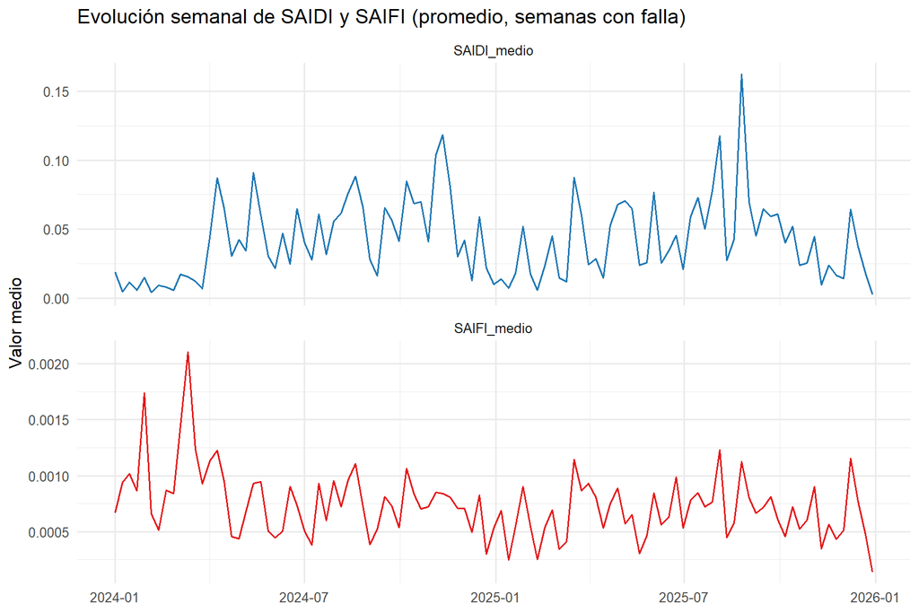

```r
if (all(c("SAIDI", "SAIFI", "hubo_falla") %in% names(data_final))) {

  data_final %>%
    filter(hubo_falla == 1) %>%
    group_by(semana) %>%
    summarise(
      SAIDI_medio = mean(SAIDI, na.rm = TRUE),
      SAIFI_medio = mean(SAIFI, na.rm = TRUE),
      n_eventos   = n(),
      .groups = "drop"
    ) %>%
    pivot_longer(c(SAIDI_medio, SAIFI_medio), names_to = "indicador", values_to = "valor") %>%
    ggplot(aes(x = semana, y = valor, color = indicador)) +
    geom_line(linewidth = 0.7) +
    facet_wrap(~indicador, ncol = 1, scales = "free_y") +
    scale_color_manual(values = c(SAIDI_medio = "#1f78b4", SAIFI_medio = "#e31a1c")) +
    labs(
      title = "Evolución semanal de SAIDI y SAIFI (promedio, semanas con falla)",
      x = NULL, y = "Valor medio"
    ) +
    theme_minimal(base_size = 12) +
    theme(legend.position = "none")

} else {
  message("SAIDI/SAIFI/hubo_falla no están en data_final todavía — se omite este gráfico.")
}
```

## NDVI vs. SAIDI en el tiempo (doble escala)

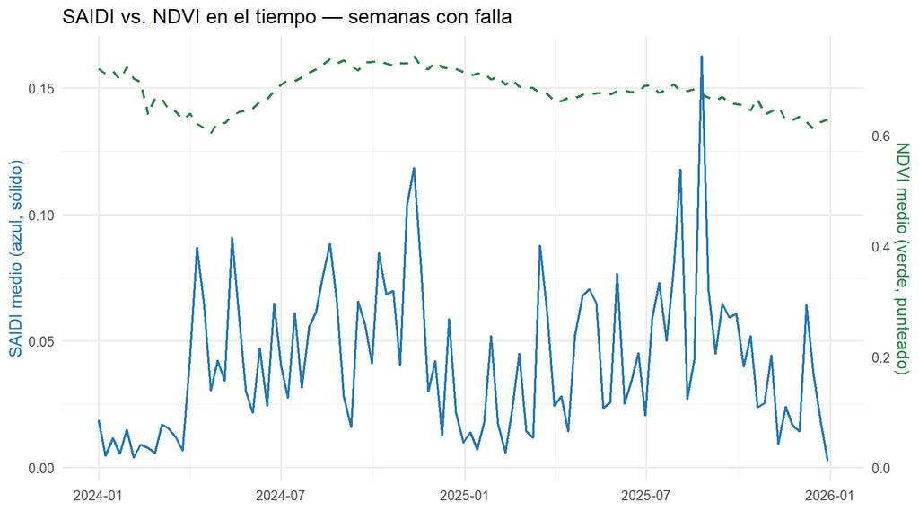

```r
if (all(c("SAIDI", "hubo_falla") %in% names(data_final))) {

  serie_combinada <- data_final %>%
    filter(hubo_falla == 1) %>%
    group_by(semana) %>%
    summarise(
      SAIDI_medio = mean(SAIDI, na.rm = TRUE),
      ndvi_medio  = mean(ndvi_semanal, na.rm = TRUE),
      .groups = "drop"
    )

  factor_escala <- max(serie_combinada$SAIDI_medio, na.rm = TRUE) /
                    max(serie_combinada$ndvi_medio, na.rm = TRUE)

  ggplot(serie_combinada, aes(x = semana)) +
    geom_line(aes(y = SAIDI_medio), color = "#1f78b4", linewidth = 0.8) +
    geom_line(aes(y = ndvi_medio * factor_escala), color = "#238443",
              linewidth = 0.8, linetype = "dashed") +
    scale_y_continuous(
      name = "SAIDI medio (azul, sólido)",
      sec.axis = sec_axis(~ . / factor_escala, name = "NDVI medio (verde, punteado)")
    ) +
    labs(
      title = "SAIDI vs. NDVI en el tiempo — semanas con falla",
      x = NULL
    ) +
    theme_minimal(base_size = 12) +
    theme(axis.title.y = element_text(color = "#1f78b4"),
          axis.title.y.right = element_text(color = "#238443"))

} else {
  message("SAIDI/hubo_falla no están en data_final todavía — se omite este gráfico.")
}
```

# Parte 6 — Exportaciones (nombre asociado a cuadrantes reales)

```r
library(htmlwidgets)

saveWidget(
  mapa_infra,
  file = file.path(UBICACION_DATA, "mapa_infraestructura_cuadrantes_reales.html"),
  selfcontained = TRUE
)
```

```r
ruta_gpkg_export <- file.path(UBICACION_DATA, "infraestructura_cuadrantes_reales.gpkg")

# Capa 1: puntos individuales de infraestructura
st_write(fallas_eventos, ruta_gpkg_export,
         layer = "fallas_eventos", delete_layer = TRUE)
```

```
## Deleting layer `fallas_eventos' using driver `GPKG'
## Writing layer `fallas_eventos' to data source
##   `D:/OneDrive - PUJ Cali/Projecto_Grado_Javeriana/Data_Project//infraestructura_cuadrantes_reales.gpkg' using driver `GPKG'
## Writing 47652 features with 7 fields and geometry type Point.
```

```r
# Capa 2: polígonos de cuadrantes reales con variables de infraestructura
st_write(cuadrantes_infra, ruta_gpkg_export,
         layer = "cuadrantes_infra_reales", delete_layer = TRUE)
```

```
## Deleting layer `cuadrantes_infra_reales' using driver `GPKG'
## Writing layer `cuadrantes_infra_reales' to data source
##   `D:/OneDrive - PUJ Cali/Projecto_Grado_Javeriana/Data_Project//infraestructura_cuadrantes_reales.gpkg' using driver `GPKG'
## Writing 344 features with 20 fields and geometry type Multi Polygon.
```

```r
# Capa 3: centroides reales usados para la descarga de NDVI
centroides_sf <- centroides_cuadrante_real %>%
  st_as_sf(coords = c("lon", "lat"), crs = 4326, remove = FALSE)

st_write(centroides_sf, ruta_gpkg_export,
         layer = "centroides_cuadrantes_reales", delete_layer = TRUE)
```

```
## Deleting layer `centroides_cuadrantes_reales' using driver `GPKG'
## Writing layer `centroides_cuadrantes_reales' to data source
##   `D:/OneDrive - PUJ Cali/Projecto_Grado_Javeriana/Data_Project//infraestructura_cuadrantes_reales.gpkg' using driver `GPKG'
## Writing 344 features with 3 fields and geometry type Point.
```

```r
st_layers(ruta_gpkg_export)
```

```
## Driver: GPKG
## Available layers:
##                     layer_name geometry_type features fields crs_name
## 1               fallas_eventos         Point    47652      7   WGS 84
## 2      cuadrantes_infra_reales Multi Polygon      344     20   WGS 84
## 3 centroides_cuadrantes_reales         Point      344      3   WGS 84
```

```r
write_csv(
  infra_cuadrante %>% st_drop_geometry(),
  file.path(UBICACION_DATA, "infraestructura_por_cuadrante_real.csv")
)

write_csv(
  ndvi_semanal,
  file.path(UBICACION_DATA, "ndvi_semanal_por_cuadrante_real.csv")
)

write_csv(
  centroides_cuadrante_real,
  file.path(UBICACION_DATA, "centroides_cuadrantes_reales.csv")
)
```

```r
saveRDS(data_final, file.path(UBICACION_DATA, "data_final_modelo_cuadrantes_reales.rds"))
write_csv(data_final, file.path(UBICACION_DATA, "data_final_modelo_cuadrantes_reales.csv"))

cat(sprintf(
  "Panel final guardado: %d filas x %d columnas (cuadrantes reales, sin Voronoi)\n",
  nrow(data_final), ncol(data_final)
))
```

```
## Panel final guardado: 36120 filas x 68 columnas (cuadrantes reales, sin Voronoi)
```

**Así se recargan estas exportaciones en otra sesión:**

```r
ruta_gpkg_export <- file.path(UBICACION_DATA, "infraestructura_cuadrantes_reales.gpkg")
st_layers(ruta_gpkg_export)

fallas_eventos          <- st_read(ruta_gpkg_export, layer = "fallas_eventos")
cuadrantes_infra        <- st_read(ruta_gpkg_export, layer = "cuadrantes_infra_reales")
centroides_cuadrante_real <- st_read(ruta_gpkg_export, layer = "centroides_cuadrantes_reales")

data_final <- readRDS(file.path(UBICACION_DATA, "data_final_modelo_cuadrantes_reales.rds"))
```

# Diccionario de variables incorporadas

```r
tribble(
  ~Variable, ~Tipo, ~Varía_en_tiempo, ~Fuente, ~Descripcion,
  "n_elementos", "Numérica", "No", "fallas_eventos.gpkg",
    "Tamaño total del inventario de infraestructura del cuadrante.",
  "n_tipos_infraestructura", "Numérica (1-5)", "No", "fallas_eventos.gpkg",
    "Diversidad de tipos de activos presentes. Exploratoria.",
  "prop_*", "Numérica (0-1)", "No", "fallas_eventos.gpkg",
    "Composición relativa de la infraestructura por tipo de elemento.",
  "ndvi_semanal", "Numérica (-1 a 1)", "Sí", "MODIS MOD13Q1, interpolado",
    "NDVI medio del cuadrante en la semana, interpolado desde composites de 16 días.",
  "log_ndvi", "Numérica", "Sí", "Derivada de ndvi_semanal",
    "log1p(ndvi_semanal + 1), para manejar valores negativos y reducir asimetría.",
  "cat_ndvi", "Categórica", "Sí", "Terciles de ndvi_semanal",
    "Baja / Media / Alta vegetación activa según distribución del período."
) %>%
  kable(caption = "Variables incorporadas al panel semana x cuadrante") %>%
  kable_styling(bootstrap_options = c("striped", "hover", "condensed")) %>%
  column_spec(5, width = "40%")
```

Variables incorporadas al panel semana x cuadrante

| Variable | Tipo | Varía_en_tiempo | Fuente | Descripcion |
| --- | --- | --- | --- | --- |
| n_elementos | Numérica | No | fallas_eventos.gpkg | Tamaño total del inventario de infraestructura del cuadrante. |
| n_tipos_infraestructura | Numérica (1-5) | No | fallas_eventos.gpkg | Diversidad de tipos de activos presentes. Exploratoria. |
| prop_* | Numérica (0-1) | No | fallas_eventos.gpkg | Composición relativa de la infraestructura por tipo de elemento. |
| ndvi_semanal | Numérica (-1 a 1) | Sí | MODIS MOD13Q1, interpolado | NDVI medio del cuadrante en la semana, interpolado desde composites de 16 días. |
| log_ndvi | Numérica | Sí | Derivada de ndvi_semanal | log1p(ndvi_semanal + 1), para manejar valores negativos y reducir asimetría. |
| cat_ndvi | Categórica | Sí | Terciles de ndvi_semanal | Baja / Media / Alta vegetación activa según distribución del período. |